# Techniki Wizualizacji Danych - PD 5

Michał Maciąg

20.11.2018r

### Opis projektu

Celem pracy domowej numer 5 było przeprowadzenie badania, mającego na celu pokazanie jak “źle” sporządzony wykres uniemożliwia właściwy odczyt danych. W tym celu wybrałem dane dotyczące powierzchni pojewództw w Polsce. Dane zawierały powierzchnie w hektarach [ha] wszystkich 16 województw, następnie powierzchnia została wyrażona w innej jednostce: tysiącach kilometrów kwadratowych [km^2]. Dzięki temu powierzchnie udało wyrazić się w czytelny sposób, liczby je opisujące są małe.

Dane te idelnie nadają się do przeprowadzenia padania, ponieważ mamy stosunkowo małą liczbę danych, zatem problem w ich odczytaniu nie będzie związany ze zbyt dużą dla odbiorcy liczbą danych. Co więcej dane dotyczą bardzo prostego zagadnienia, więc nie powinny wzbudzać w odbiory pewnego rodzają lęku, mogącego zaburzyć wynik eksperymentu. Pozwoli to zbadać jedynie wpływ rodzaju wykresu na jego czytelność.

### Dane dotyczące powierzchni województw w Polsce

```
##           Wojewodztwo Powierzchnia
## 1         MAZOWIECKIE         35.6
## 2       WIELKOPOLSKIE         29.8
## 3           LUBELSKIE         25.1
## 4 WARMIŃSKO-MAZURSKIE         24.2
## 5  ZACHODNIOPOMORSKIE         22.9
## 6           PODLASKIE         20.2
```

### Mało czytelny wykres typu “bubble plot”

Pierwszy wygenerowany na podstawie danych wykres miał na celu “zmylić przeciwnika”, to znaczy przedtawić dane w sposób poprawny (bez jakiego kolwiek oszukiwania), ale jednocześnie w sposób maksymalnie nie czytelny i uniemożliwijący ich analizowanie. W tym celu zdecydowałem się na wykres bąbelkowy (bubble plot). Jest on bardzo efektowny ale niestety nie efektywny.

Na planszy mamy 16 losowo rozmieszczonych kółek, których rozmiar koduje powierzchnie województwa. Jest to jeden z najgorszych sposobów prezentacji tego typu danych. Tego typu wykres mógłby się jeszcze obrnonić w sytuacji, gdybyśmy mieli do czynienia z danymi znacznie różniącymi się wielkością. Jednak w sytuacji, gdy powierzchnie wielu województw są praktycznie identyczne, wykres uniemożliwia porównywanie ich wielkości.

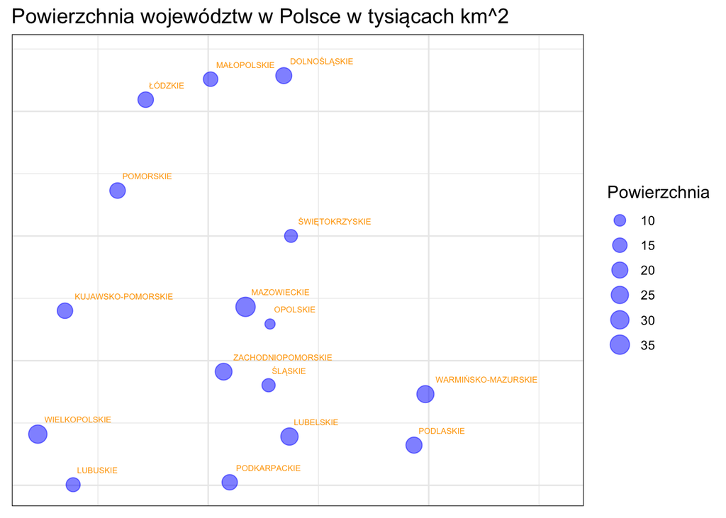

### Bardzo czytelny wkres typu “lollipop”

Drugi wykres został zrobiony tak, aby był jak najbardziej czytelny i łatwy w odczycie. Wykorzystano wykres lizakowy (lollipop). Powierzchnia województwa jest kodowana jako długość odcinka, dodatkowo na końcu odcinka znajduje się etykietka z napisaną liczbowo powierzchnią, co więcej województwo są uszeregowane rosnąco, od najmniejszego do największego. Ten typ wykresu pozwala w naturalny, czytelne i bardzo prosty sposób porównywać rozmiary województw. Kożystając uważnie z tego wykresu praktycznie nie możliwe jest popełnienie błędu podczas analizowania danych.

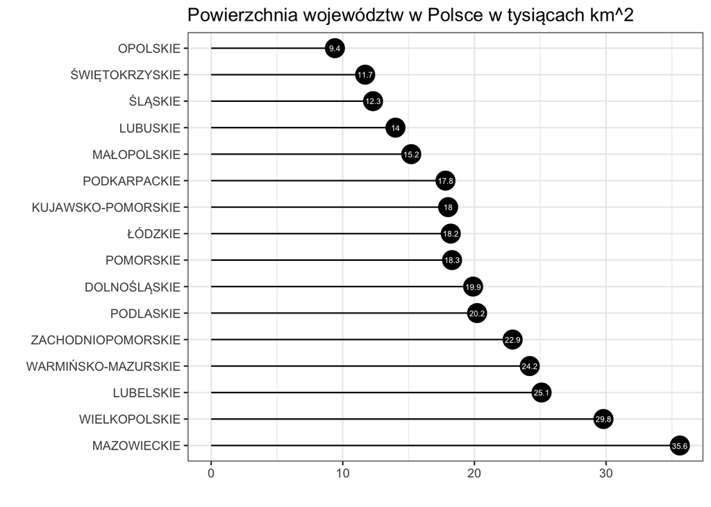

### Treść ankiety

##### 4.“Która odpowiedź jest poprawna ?”

##### A) Wamińsko-Mazurskie < Zachodniopomorskie < Lubelskie

##### B) Wamińsko-Mazurskie < Lubelskie < Zachodniopomorskie

##### C) Lubelskie < Zachodniopomorskie < Wamińsko-Mazurskie

##### D) Zachodniopomorskie < Wamińsko-Mazurskie < Lubelskie

##### Poprawna odpowiedz: D

### Wyniki ankiety

Udało się uzyskać odpowiedzi od 25 osób.

### Wyniki I pytania

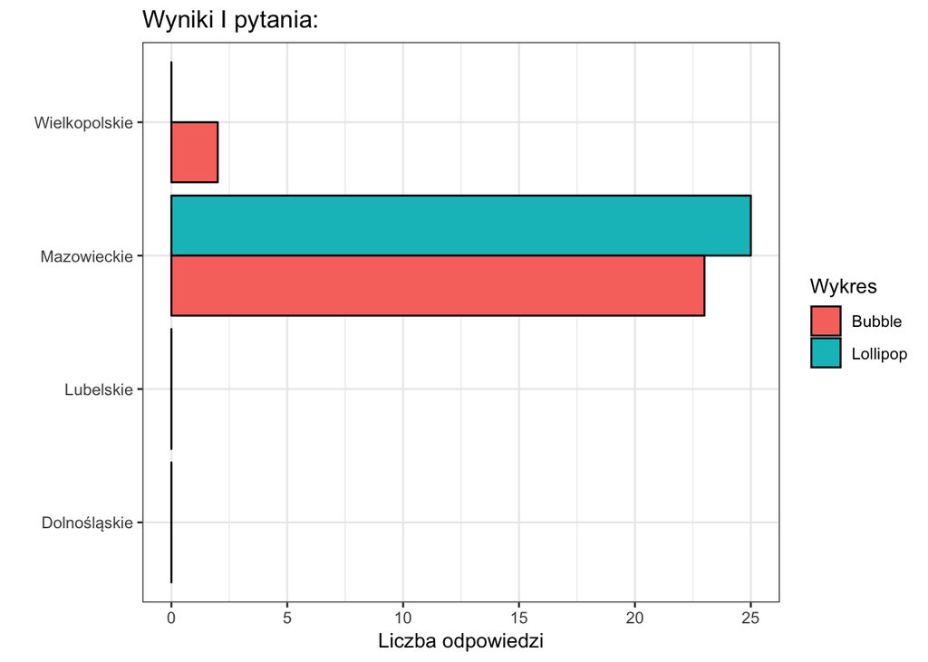

### Wyniki II pytania

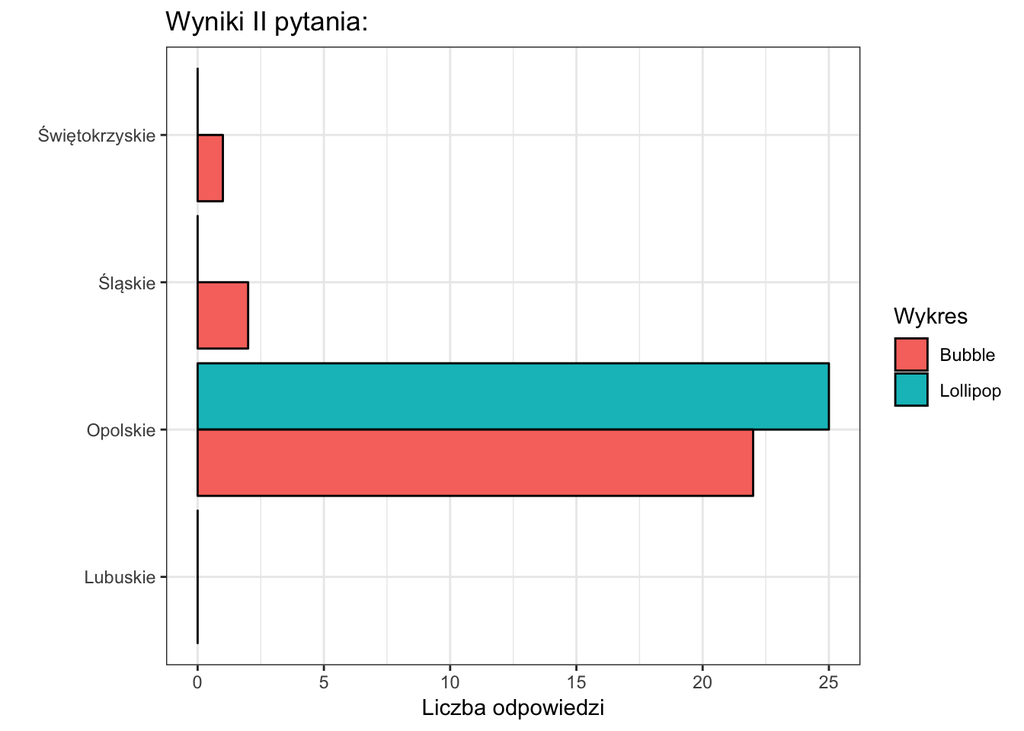

### Wyniki III pytania

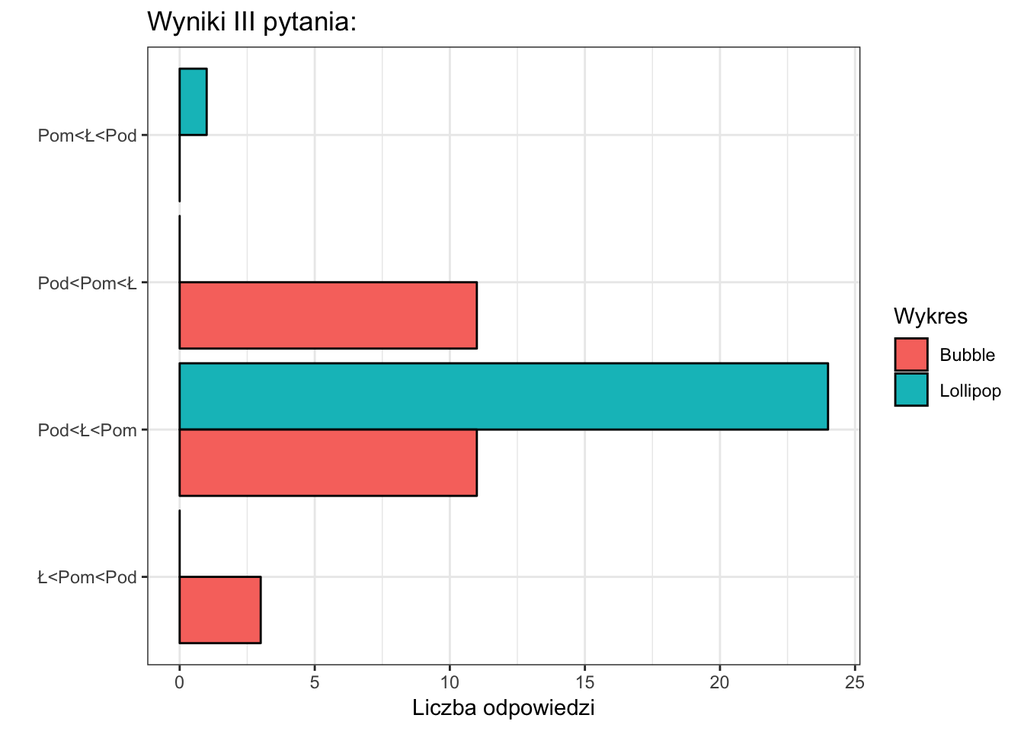

### Wyniki IV pytania

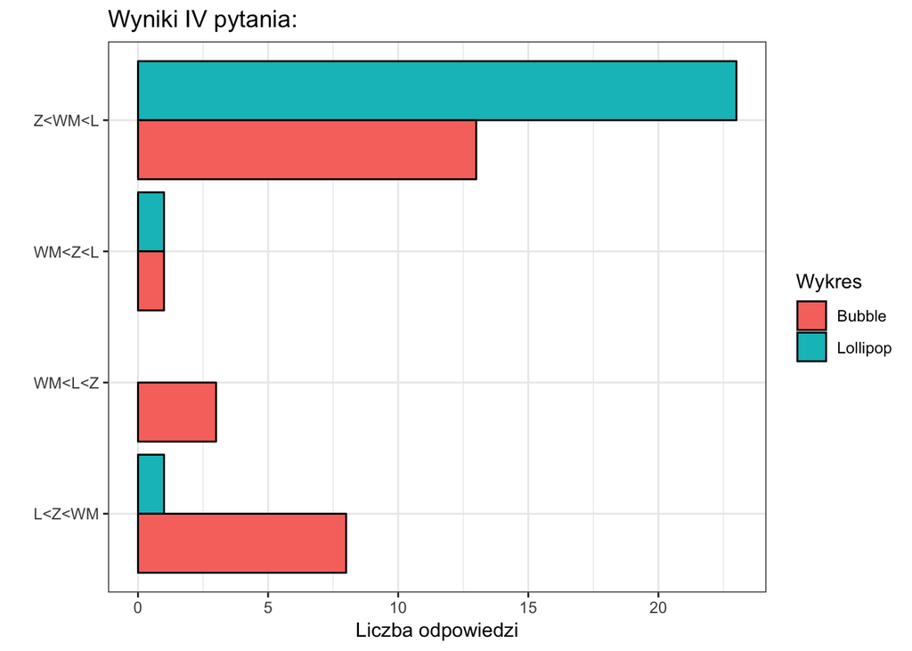

### Podsumowanie

W pytaniach 1 i 2 (prostszych) respondenci potrafili udzeilić w większości poprawnych odpowiedzi zarówno korzystając z wykresu I jak i II, widać niewielką przewagę wykresu 2. Natomiast w pytaniach 3 i 4 (trudniejszych) repsondenci nie byli w stanie udzielić poprawnej odpowiedzi kozystając z wykresu I, padają tam można powiedzieć losowe odpowiedzi. Natomiast korzystając z wykresu II zdecydowana większość udzieliła poprawnej odpoweidzi. Jak zatem wytłumaczyć błędne odpowiedzi udzilone przez responedntów w drugiej części badania (wykres lizakowy) ? Po pierwsze możmy założyć, że dane zostały dobrze odczytane, jednak respondent mógł źle zaznaczyć odpowiedź. Po drugie respondent znudzony ankietą (były to pytania 5-8) mógł zaznaczyć losową odpowiedz nie zaznajamiając się z wykresem. Reasumując generalnie wyniki badania potwierdziły moje przypuszczenia. Rzeczywiście na podstawie wykresu I nie dało się prawidłowo odczytać zakodowanych danych. Natomiast wykres II pozwolił poprawnie odczytać dowlne informacje.